# Project (Signature Assignment)

# (3) Random Forest:

### (l) Evaluation of fit of models with holdout method - Random Forest:

```r
library(randomForest)
model_RF_handout <- randomForest(handout_train$Class ~., data = handout_train)
summary(model_RF_handout)
```

```
                Length Class  Mode
call                3  -none- call
type                1  -none- character
predicted       35570  factor numeric
err.rate         1500  -none- numeric
confusion           6  -none- numeric
votes           71140  matrix numeric
oob.times       35570  -none- numeric
classes             2  -none- character
importance         30  -none- numeric
importanceSD        0  -none- NULL
localImportance     0  -none- NULL
proximity           0  -none- NULL
ntree               1  -none- numeric
mtry                1  -none- numeric
forest             14  -none- list
y               35570  factor numeric
test                0  -none- NULL
inbag               0  -none- NULL
terms               3  terms  call
```

```r
print(model_RF_handout)
```

```
Call:
 randomForest(formula = handout_train$Class ~ ., data = handout_train)
               Type of random forest: classification
                     Number of trees: 500
No. of variables tried at each split: 5

        OOB estimate of  error rate: 0.08%
Confusion matrix:
      0  1  class.error
0 35497  5 0.0001408371
1    24 44 0.3529411765
```

```r
pred_RF_handout <- predict(model_RF_handout, handout_test_fulldata) #Against test dataset
pred_RF_handout.1 <- predict(model_RF_handout, handout_validation_fulldata) #Against validation dataset
```

#### Evaluation of the fit of model with Absolute Accuracy - Random Forest against the testing & validation dataset; which is partitioned on full dataset to determine and ensure the fitting of the model on the data to be generalized.

```r
confusionMatrix(pred_RF_handout, handout_test_class)  #Evaluation (Accuracy: 0.9996, No Information Rate: 0.9983)
```

```
Confusion Matrix and Statistics

          Reference
Prediction     0     1
         0 71097    25
         1     2    99

               Accuracy : 0.9996
                 95% CI : (0.9994, 0.9998)
    No Information Rate : 0.9983
    P-Value [Acc > NIR] : < 2.2e-16

                  Kappa : 0.8798
 Mcnemar's Test P-Value : 2.297e-05

            Sensitivity : 1.0000
            Specificity : 0.7984
         Pos Pred Value : 0.9996
         Neg Pred Value : 0.9802
             Prevalence : 0.9983
         Detection Rate : 0.9982
   Detection Prevalence : 0.9986
      Balanced Accuracy : 0.8992

       'Positive' Class : 0
```

```r
confusionMatrix(pred_RF_handout.1, handout_validation_class)  #Evaluation (Accuracy: 0.9996, No Information Rate: 0.9981)
```

```
Confusion Matrix and Statistics

          Reference
Prediction     0     1
         0 71164    27
         1     4   109

               Accuracy : 0.9996
                 95% CI : (0.9994, 0.9997)
    No Information Rate : 0.9981
    P-Value [Acc > NIR] : < 2.2e-16

                  Kappa : 0.8753
 Mcnemar's Test P-Value : 7.772e-05

            Sensitivity : 0.9999
            Specificity : 0.8015
         Pos Pred Value : 0.9996
         Neg Pred Value : 0.9646
             Prevalence : 0.9981
         Detection Rate : 0.9980
   Detection Prevalence : 0.9984
      Balanced Accuracy : 0.9007

       'Positive' Class : 0
```

#### We can say that, results of prediction classification are most probably giving the generalized output and hence, Random Forest model is fit and accurate to use further for analysis.

### (m) Evaluation with k-fold cross-validation - Random Forest:

```r
RF.fit <- train(factor(Class) ~ ., data = dataf3, method = "rf", trControl = trainControl(method = "cv", number = 2, selectionFunction = "best", verboseIter = TRUE))
RF.fit
```

```
Random Forest

71202 samples
   30 predictor
    2 classes: '0', '1'

No pre-processing
Resampling: Cross-Validated (2 fold)
Summary of sample sizes: 35601, 35601
Resampling results across tuning parameters:

  mtry  Accuracy   Kappa
   2    0.9992416  0.7373800
  16    0.9992978  0.7748148
  30    0.9990590  0.7119529

Accuracy was used to select the optimal model using the largest value.
The final value used for the model was mtry = 16.
```

### (n) Tuning of models - Random Forest:

```r
library(randomForest)
model_RF_tuned <- randomForest(credit_training$Class ~., data = credit_training, ntree = 80, norm.votes = FALSE, importance = T, mtry = 16)
summary(model_RF_tuned)
```

```
                Length Class  Mode
call                 7 -none- call
type                 1 -none- character
predicted        53403 factor numeric
err.rate           240 -none- numeric
confusion            6 -none- numeric
votes           106806 matrix numeric
oob.times        53403 -none- numeric
classes              2 -none- character
importance         120 -none- numeric
importanceSD        90 -none- numeric
localImportance      0 -none- NULL
proximity            0 -none- NULL
ntree                1 -none- numeric
mtry                 1 -none- numeric
forest              14 -none- list
y                53403 factor numeric
test                 0 -none- NULL
inbag                0 -none- NULL
terms                3 terms  call
```

```r
print(model_RF_tuned)
```

```
Call:
 randomForest(formula = credit_training$Class ~ ., data = credit_training,      ntree = 80, norm.votes = FALSE, importance = T, mtry = 16)
               Type of random forest: classification
                     Number of trees: 80
No. of variables tried at each split: 16

        OOB estimate of  error rate: 0.08%
Confusion matrix:
      0  1  class.error
0 53301  9 0.0001688239
1    32 61 0.3440860215
```

```r
pred_RF_tuned <- predict(model_RF_tuned, credit_testing_fulldata)
```

#### Evaluation of tuned model “Random Forest” - individual model analysis with Absolute Accuracy & AUC:

```r
confusionMatrix(pred_RF_tuned, credit_testing_fulldata$Class) #Evaluation (Accuracy: 0.9996, No Information Rate: 0.9983)
```

```
Confusion Matrix and Statistics

          Reference
Prediction     0     1
         0 71075    26
         1     3    97

               Accuracy : 0.9996
                 95% CI : (0.9994, 0.9997)
    No Information Rate : 0.9983
    P-Value [Acc > NIR] : < 2.2e-16

                  Kappa : 0.8698
 Mcnemar's Test P-Value : 4.402e-05

            Sensitivity : 1.0000
            Specificity : 0.7886
         Pos Pred Value : 0.9996
         Neg Pred Value : 0.9700
             Prevalence : 0.9983
         Detection Rate : 0.9982
   Detection Prevalence : 0.9986
      Balanced Accuracy : 0.8943

       'Positive' Class : 0
```

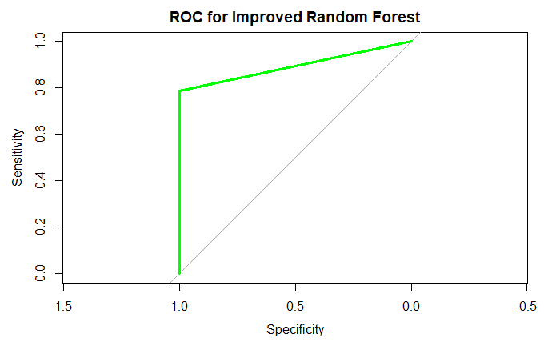

```r
library(pROC)
roc_RF_tuned <- roc(as.numeric(test_class_fulldata), as.numeric(pred_RF_tuned))
plot.roc(roc_RF_tuned, col="Green", lwd=3, main = "ROC for Improved Random Forest")
```

```r
auc(roc_RF_tuned) #Area under the curve: 0.8902298
```

```
Area under the curve: 0.8943
```

### (O) Comparision of tuned/improved models:

#### Let’s compare each trained models with it’s AUC (i.e. Area Under Curve)

```r
library(pROC)
library(ROCR)
table(pred_kNN_tuned)
```

```
pred_kNN_tuned
    0     1
71103    98
```

```r
table(pred_NB_tuned)
```

```
pred_NB_tuned
    0     1
69481  1720
```

```r
table(pred_RF_tuned)
```

```
pred_RF_tuned
    0     1
71101   100
```

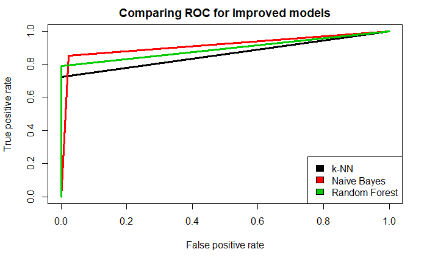

```r
preds_list <- list(as.numeric(pred_kNN_tuned), as.numeric(pred_NB_tuned), as.numeric(pred_RF_tuned))
m <- length(preds_list)
actuals_list <- rep(list(as.numeric(credit_testing_fulldata$Class)), m)
pred <- prediction(preds_list, actuals_list)
rocs <- performance(pred, "tpr", "fpr")
plot(rocs, col = as.list(1:m), main = "Comparing ROC for Improved models",lwd=3 , pch=17)
legend("bottomright", c("k-NN","Naive Bayes","Random Forest"), fill = 1:m)
```

### (p) Interpretations of results:

Hence, comparatively all the trained models works and are proved be achieving good percent of accuracy in performing predictive classification of the target variable.

Now, let’s build a Stacked Ensemble model which will eventually combine the predictions of all the primary models (i.e. of different types).

# Phase 6 - Deployment:

### (q) Construction of stacked ensemble model:

#### Voting (i.e. Stacked Learner)

```r
# The majority vote of all trained, evaluated and tuned machine learning model:
pred_majority <- (ifelse(pred_RF_tuned==0 & pred_kNN_tuned==0,0,ifelse(pred_RF_tuned==0 & pred_NB_tuned==0,0,ifelse(pred_kNN_tuned==0 & pred_NB_tuned==0,0,1))))


summary(pred_majority)
table(pred_majority)
```

[output not shown]

#### Evaluating the Stacked Ensemble model based on Absolute Accuracy & AUC:

```r
auc(vote_preds, vote_actuals, partial.auc = FALSE)
```

[output not shown]

```
Area under the curve: 0.954
```

#### Area Under Curve (AUC) = 0.954